# Spatial `K`luster Analysis by Tree Edge Removal

Maxwell

2022-04-11

Tutorial for regionalization function `skater`.

References:

1. AssunÇão RM, Neves MC, Câmara G, Da Costa Freitas C. Efficient regionalization techniques for socio‐economic geographical units using minimum spanning trees. International Journal of Geographical Information Science. 2006;20: 797–811. doi:10.1080/13658810600665111
2. https://r-spatial.github.io/spdep/reference/skater.html

# 1 Preparations

## 1.1 Load libraries

## 1.2 Environment

```r
# rgb(73, 81, 112, maxColorValue = 255): "#495170"
col.os <- "#414a4c"
col.cb <- "#b0b7c6"
col.rm <- "#e3256b"
theme_set(theme_minimal(base_family = "Candara"))
options(dplyr.summarise.inform = TRUE)
```

# 2 Load DataSets

**> ?spdep::bhicv**  
**Data set with 4 life condition indices of Belo Horizonte region**

The data are collected inthe Atlas of condition indices published by the Joao Pinheiro Foundation and UNDP.

**Format**: A shape polygon object with seven variables  
**id**: The identificator  
**Name**: Name of city  
**Population**: The population of city  
**HLCI**: Health Life Condition Index  
**ELCI**: Education Life Condition Index  
**CLCI**: Children Life Condition Index  
**ELCI_1**: Economic Life Condition Index

```r
bh <- sf::read_sf(
    system.file("etc/shapes/bhicv.shp", package = "spdep"),
    quiet = TRUE
)
print(st_crs(bh))
```

```
## Coordinate Reference System: NA
```

```r
st_crs(bh) <- "+proj=longlat +ellps=WGS84"  # set CRS
```

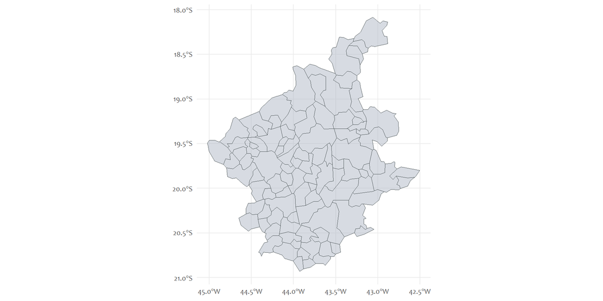

```r
ggplot() +
    geom_sf(mapping = aes(), data = bh,
            color = col.os, fill = col.cb, size = 0.2, alpha = 0.5)
```

# 3 Preprocessing for skater algorithm

## 3.1 Standardize Node 4 Features

```r
bh.index.scale <- scale(
    x = bh %>% as.data.frame() %>% select(HLCI, ELCI, CLCI, ELCI_1)
)
bh.index.scale.df <- bh.index.scale %>% as.data.frame()
```

## 3.2 Compute Neighboorhod list with `spdep::poly2nb`

```r
bh.nb <- spdep::poly2nb(bh)
spdep::card(bh.nb)
```

```
##  [1] 10  3  4  3  3  5  3  5  6  4  5  7  5  2  7  5  3  5  7  5  8  7  4  4  1
## [26]  6  3  4  3  5  5  6  4  5  5  6 13  6  5  5  5  6  7  5  2  7  7  4  7  4
## [51]  5  9  2  6  4  6  7  4  6  6  9  5  4  5  6 11  4  8  9  5  5  9  5  3 10
## [76]  6  3  7  6  5  3  5  5  4  6  6  4  6  5  4  6  4  2  3  3  2  2  2
```

## 3.3 Computing costs with `spdep::nbcosts`

**method**:

“mahalanobis”  
or  
“euclidean”, “maximum”, “manhattan”, “canberra”, “binary” or “minkowisk”

```r
bh.costs <- spdep::nbcosts(
    nb = bh.nb,
    data = bh.index.scale,
    method = c("euclidean", "maximum", "manhattan", "canberra",
               "binary", "minkowski", "mahalanobis")
)
cat(class(bh.costs))
```

```
## nbdist
```

## 3.4 Making listw with `spdep::nb2listw`

```r
unlist(bh.costs)
```

[output not shown]

[output cut: 58 more lines]

```r
bh.listw <- spdep::nb2listw(neighbours = bh.nb, bh.costs, style = "B")
bh.listw
```

```
## Characteristics of weights list object:
## Neighbour list object:
## Number of regions: 98
## Number of nonzero links: 508
## Percentage nonzero weights: 5.289463
## Average number of links: 5.183673
##
## Weights style: B
## Weights constants summary:
##    n   nn       S0       S1       S2
## B 98 9604 1027.424 5192.868 55983.97
```

## 3.5 Find a Minimum Spanning Tree with `spdep::mstree` and Plot

**nbw**: An object of listw class returned by nb2listw function. See this help for details.

**ini**: The initial node in the minimal spanning tree. Heuristic

```r
bh.mst <- spdep::mstree(nbw = bh.listw, ini = 5)
cat(class(bh.mst))
```

```
## mst matrix
```

```r
cat(dim(bh.mst))
```

```
## 97 3
```

```r
bh.mst[1:3, ]
```

```
##      [,1] [,2]      [,3]
## [1,]    5   12 1.2951120
## [2,]   12   13 0.6141101
## [3,]   13   11 0.7913745
```

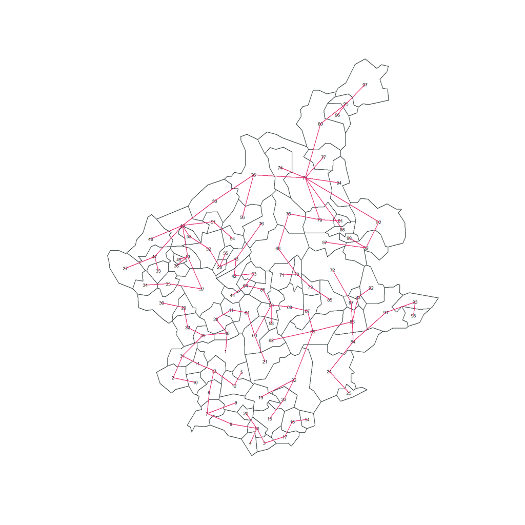

```r
plot(sf::st_geometry(bh), border = col.os)
# ?plot.mst
plot(bh.mst, coordinates(as(bh, "Spatial")),
     cex.circles = 0., cex.labels = 0.5, fg = col.os, add = TRUE,
     col = col.rm)
```

# 4 Regionalization with `spdep::skater`

**Arguments**  
**edges**: A matrix with 2 colums with each row is an edge  
**data**: A data.frame with data observed over nodes.  
**ncuts**: The number of cuts. `This value specifiedis not the number of clusters, but the number of cuts in the graph, one less than the number of clusters`.  
**crit**: A scalar or two dimensional vector with criteria for groups. Examples: limits of group size or limits of population size. If scalar, is the minimum criteria for groups.  
**vec.crit**: A vector for evaluating criteria.  
**method**: “mahalanobis” or “euclidean”, “maximum”, “manhattan”, “canberra”, “binary” or “minkowisk”  
**p**: The power of the Minkowski distance.  
**cov**: The covariance matrix used to compute the mahalanobis distance.  
**inverted**: logical. If ‘TRUE’, ‘cov’ is supposed to contain the inverse of the covariance matrix.

**Value**  
**groups**: A vector with length equal the number of nodes. Each position identifies the group of node.  
**edges.groups**: A list of length equal the number of groups with each element is a set of edges.  
**not.prune**: A vector identifying the groups with are not candidates to partition.  
**candidates**: A vector identifying the groups with are candidates to partition.  
**ssto**: The total dissimilarity in each step of edge removal.

## 4.1 ncuts = 2 (ncluster = 3)

```r
bh.reg.1 <- spdep::skater(
    edges = bh.mst[, 1:2],
    data = bh.index.scale.df,
    ncuts = 2
)
summary(bh.reg.1)
```

```
##              Length Class  Mode
## groups       98     -none- numeric
## edges.groups  3     -none- list
## not.prune     0     -none- NULL
## candidates    3     -none- numeric
## ssto          1     -none- numeric
## ssw           3     -none- numeric
## crit          2     -none- numeric
## vec.crit     98     -none- numeric
```

```r
cat(names(bh.reg.1), sep = "\n")
```

```
## groups
## edges.groups
## not.prune
## candidates
## ssto
## ssw
## crit
## vec.crit
```

```r
table(bh.reg.1$groups)
```

```
##
##  1  2  3
## 18 23 57
```

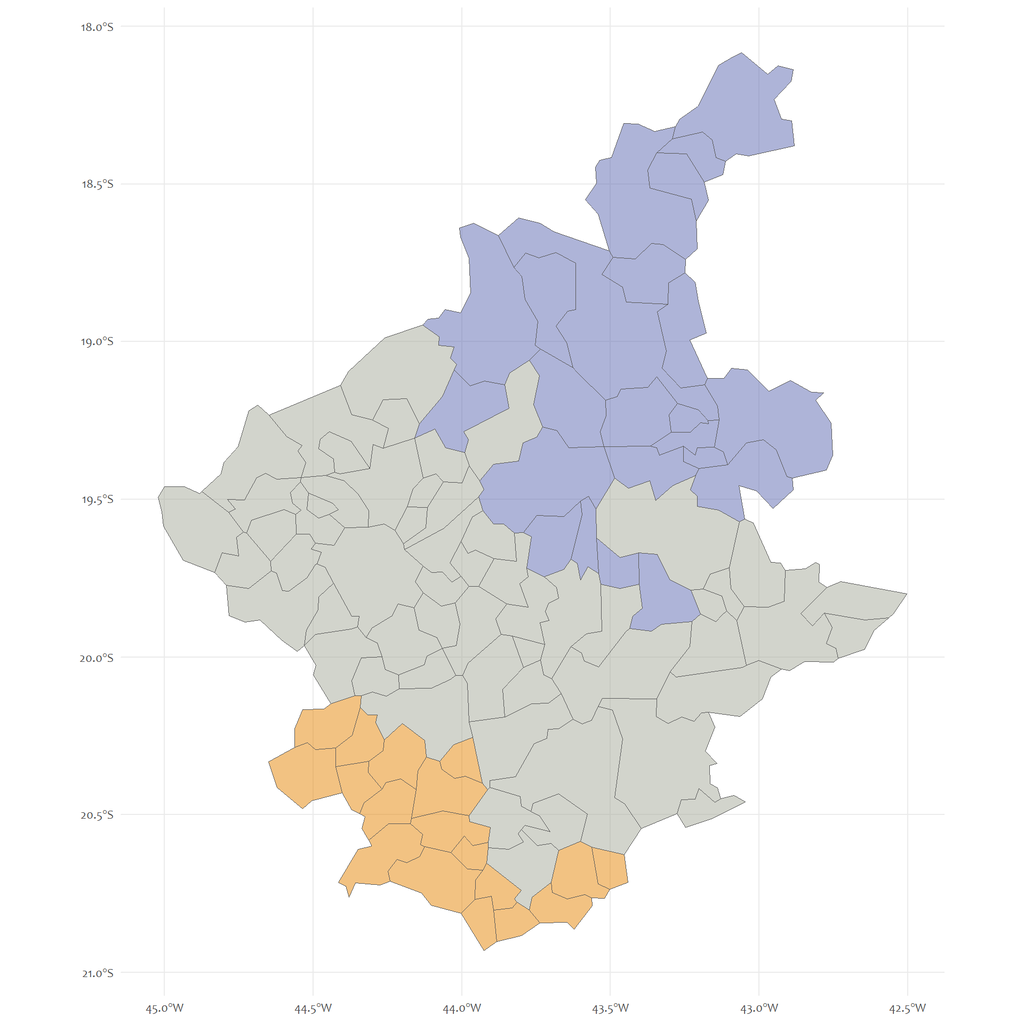

```r
bh %>% bind_cols(
    tibble(GROUP = factor(bh.reg.1$groups, levels = c(1, 2, 3)))
) %>% ggplot() +
    geom_sf(mapping = aes(fill = GROUP),
            size = 0.2, alpha = 0.5) +
    scale_fill_carto_d(name = "Region: ", palette = "Vivid") +
    theme(legend.position = "none")
```

## 4.2 ncuts = 3 (ncluster = 4)

```r
bh.reg.1 <- spdep::skater(
    edges = bh.mst[, 1:2],
    data = bh.index.scale.df,
    ncuts = 3
)
summary(bh.reg.1)
```

```
##              Length Class  Mode
## groups       98     -none- numeric
## edges.groups  4     -none- list
## not.prune     0     -none- NULL
## candidates    4     -none- numeric
## ssto          1     -none- numeric
## ssw           4     -none- numeric
## crit          2     -none- numeric
## vec.crit     98     -none- numeric
```

```r
table(bh.reg.1$groups)
```

```
##
##  1  2  3  4
## 18 23 55  2
```

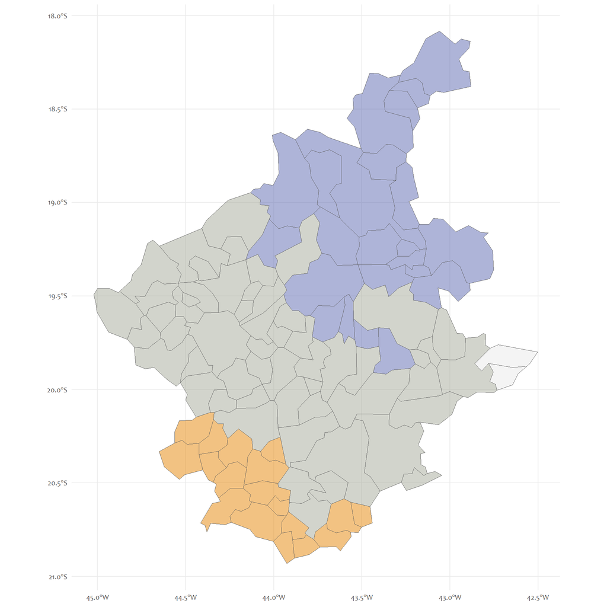

```r
bh %>% bind_cols(
    tibble(GROUP = factor(bh.reg.1$groups, levels = c(1, 2, 3)))
) %>% ggplot() +
    geom_sf(mapping = aes(fill = GROUP),
            size = 0.2, alpha = 0.5) +
    scale_fill_carto_d(name = "Region: ", palette = "Vivid") +
    theme(legend.position = "none")
```

## 4.3 ncuts = 4 (ncluster = 5)

```r
bh.reg.1 <- spdep::skater(
    edges = bh.mst[, 1:2],
    data = bh.index.scale.df,
    ncuts = 4
)
summary(bh.reg.1)
```

```
##              Length Class  Mode
## groups       98     -none- numeric
## edges.groups  5     -none- list
## not.prune     0     -none- NULL
## candidates    5     -none- numeric
## ssto          1     -none- numeric
## ssw           5     -none- numeric
## crit          2     -none- numeric
## vec.crit     98     -none- numeric
```

```r
table(bh.reg.1$groups)
```

```
##
##  1  2  3  4  5
## 18 15 55  2  8
```

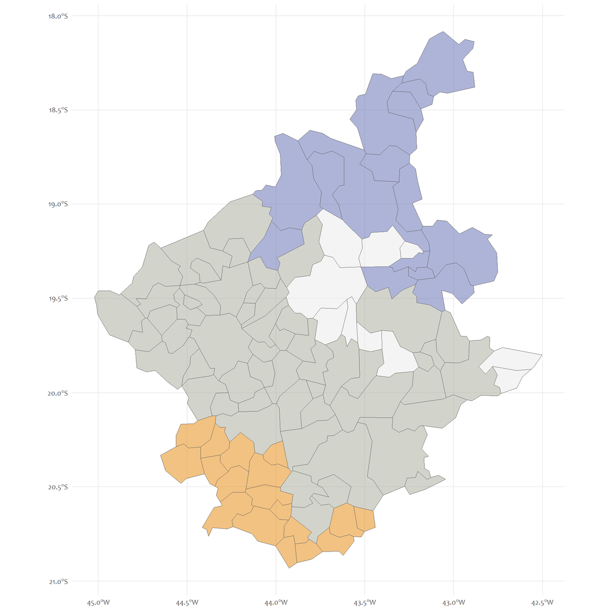

```r
bh %>% bind_cols(
    tibble(GROUP = factor(bh.reg.1$groups, levels = c(1, 2, 3)))
) %>% ggplot() +
    geom_sf(mapping = aes(fill = GROUP),
            size = 0.2, alpha = 0.5) +
    scale_fill_carto_d(name = "Region: ", palette = "Vivid") +
    theme(legend.position = "none")
```